# Microstructure Analysis (DRAFT)

Nathan Switzner and Joel Anderson

August 09, 2021

This report is automatically generated based on the data collection file produced by Pacific Gas and Electric (PG&E) Facilities Integrity Management Program (FIMP) microstructural analysis team. The microstructural analysis team regularly performs two types of analysis for microstructures: grain size and percent dark phase (pearlite) estimation. These two types of analysis are important inputs to strength, grade, and vintage estimation procedures. Two methods are used for each analysis: counting and comparison methods. The counting and comparison methods for grain size are based on the ASTM E112 Jeffries planimetric method and comparison method, respectively. The counting method for dark phase is based on ASTM E562, and the comparison method for dark phase estimation was developed by PG&E.

# 1 Evaluator Metrics

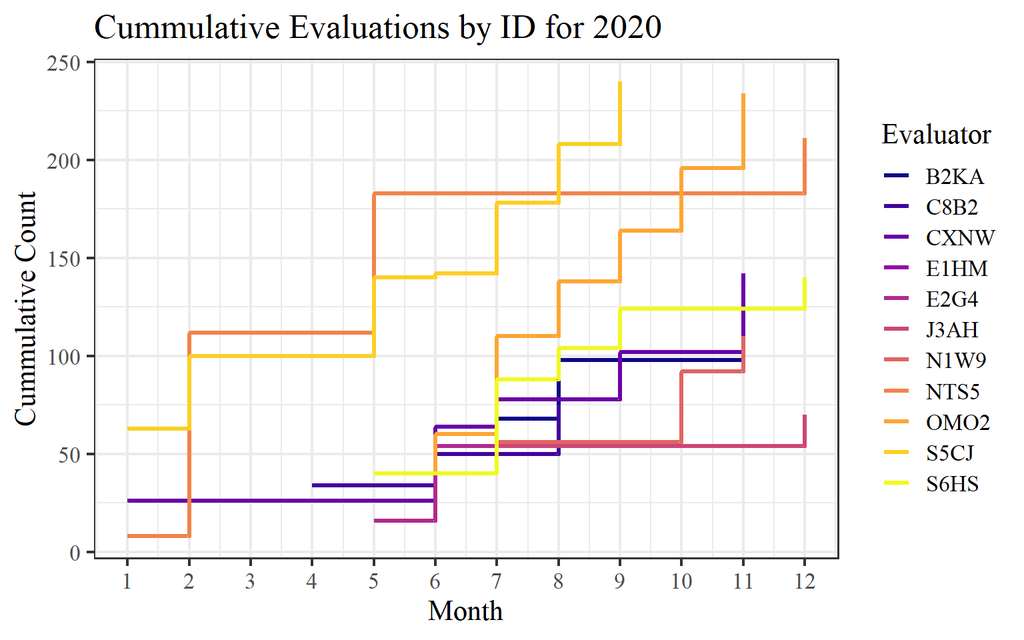

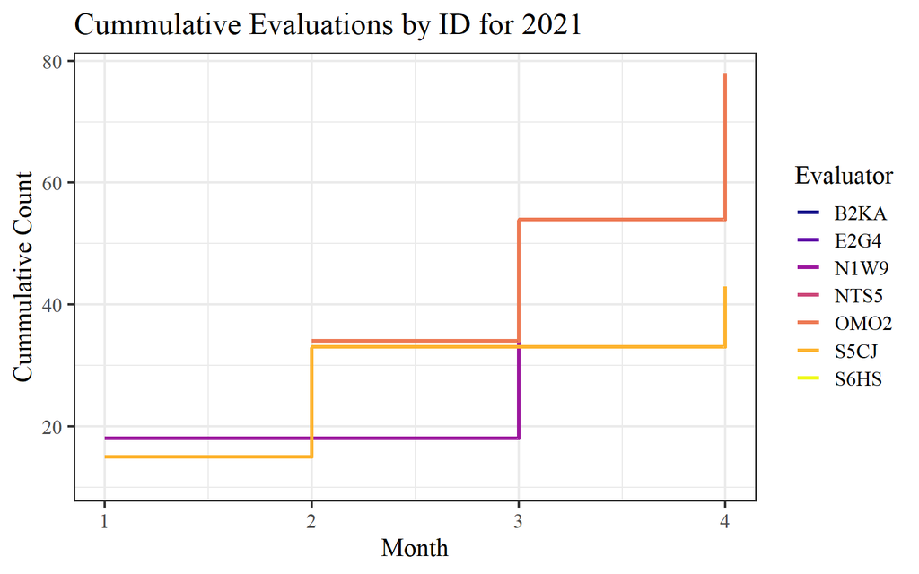

## 1.1 Evaluator Metrics Table

This table can be sorted by any field by clicking on the arrows at the column head.

|  | ID | Jan | Feb | Mar | Apr | Total |
| --- | --- | --- | --- | --- | --- | --- |
| 1 | N1W9 | 18 |  | 35 |  | 53 |
| 2 | NTS5 | 48 |  |  |  | 48 |
| 3 | S5CJ | 15 | 18 |  | 10 | 43 |
| 4 | S6HS | 15 |  |  |  | 15 |
| 5 | B2KA |  | 20 |  |  | 20 |
| 6 | OMO2 |  | 34 | 20 | 24 | 78 |
| 7 | E2G4 |  |  | 11 |  | 11 |

## 1.2 Evaluator Performance vs Averages Plots

The plots below indicate how the evaluations by each individual evaluator differ from the average of all evaluations.

Mean Linear Intercept Grain Size (MLI-GS) by the Counting Method:

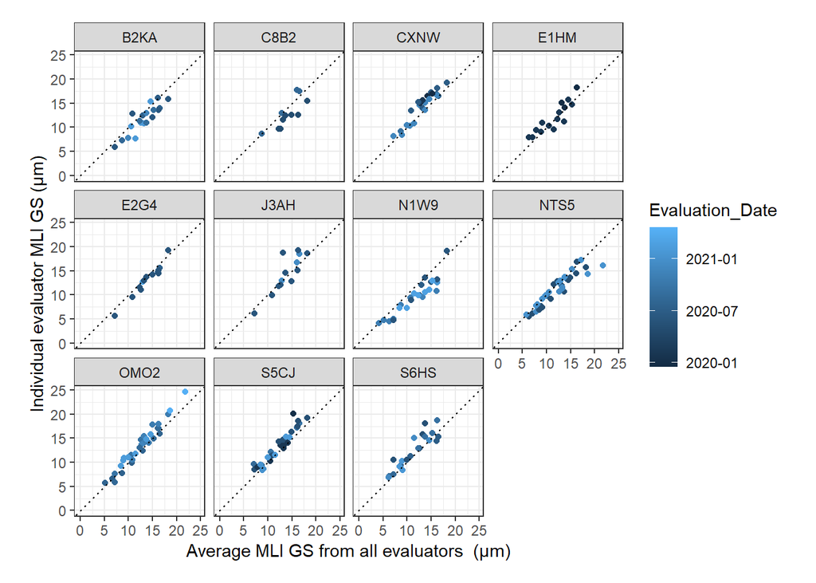

Individual performance for MLI GS (μm) by counting method (skips included)

Mean Linear Intercept Grain Size (MLI-GS) by the Comparison Method:

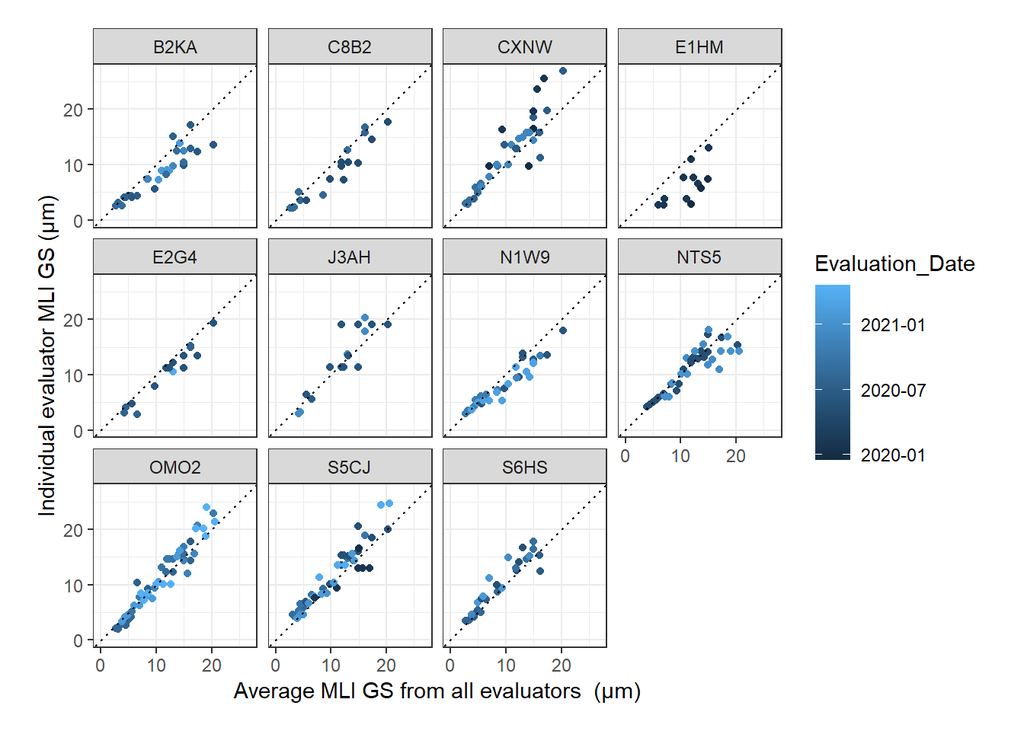

Individual performance for MLI GS (μm) by comparison method (skips included)

Dark Phase (DP) by the Counting Method:

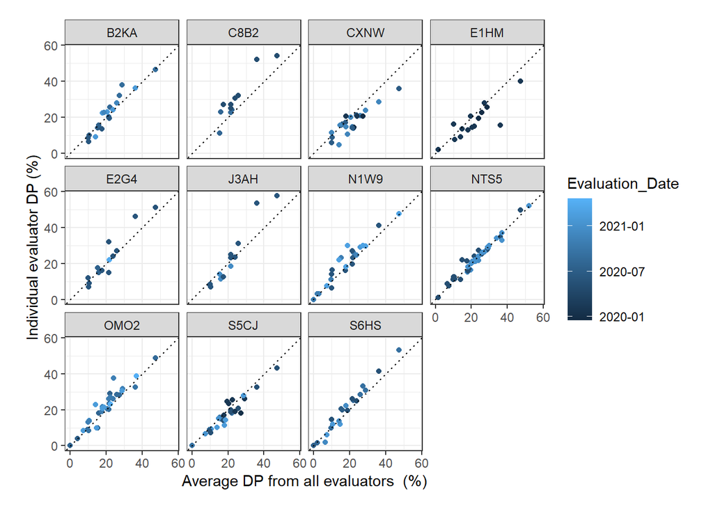

Individual performance for DP (%) by counting method (skips included)

Dark Phase (DP) by the Comparison Method:

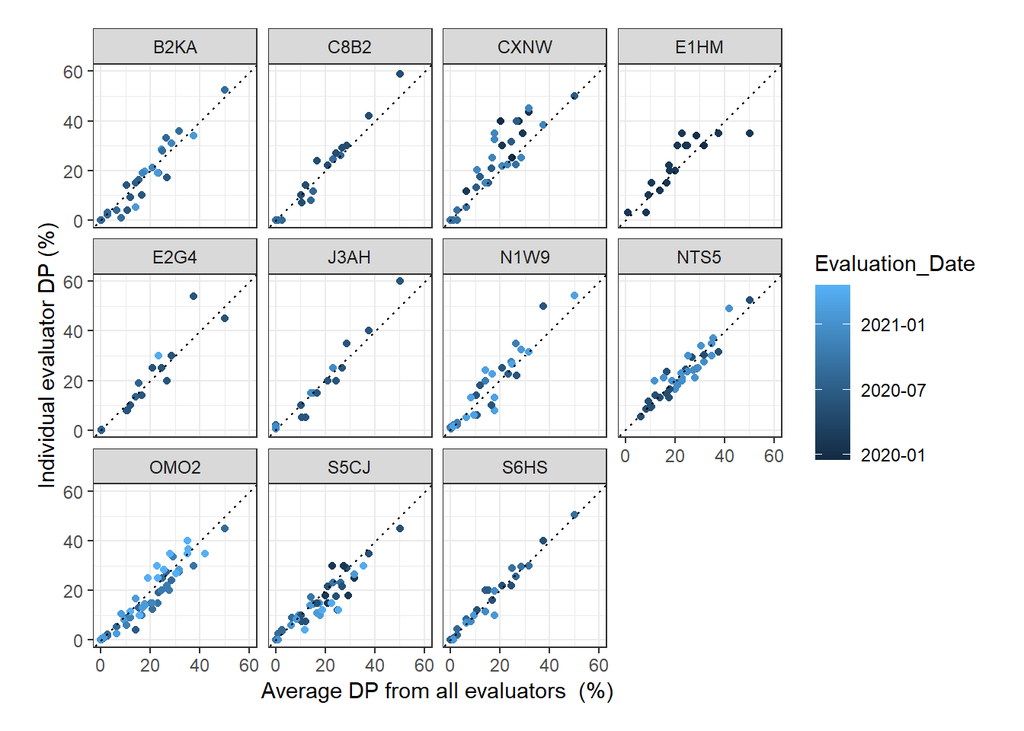

Individual performance for DP (%) by comparison method (skips included)

## 1.3 Quality Control Skips and Reasons

The purpose of this table is for evaluators to identify their common errors and self correct.

|  | Evaluator | Date | Path | Method | DP_pct | MLI_GS | Skip_Reason |
| --- | --- | --- | --- | --- | --- | --- | --- |
| 1 | B2KA | 2020-06-10 | DNV-Modesto-Lab_Long\M-24L | Comparison |  | 5.6 | MLI GS too low for this sample |
| 2 | B2KA | 2020-06-10 | DNV-Modesto-Lab_Long\M-1L | Comparison | 34 |  | DP too high for this sample |
| 3 | B2KA | 2020-06-10 | DNV-Modesto-Lab_Long\M-15L | Comparison | 4 |  | DP too low for this sample |
| 4 | B2KA | 2020-06-10 | DNV-Modesto-Lab_Long\M-21L | Comparison | 10 |  | DP too low for this sample |
| 5 | B2KA | 2020-08-28 | Modesto-Rep-DNV\5 NDT_1 | Comparison |  | 7.5 | MLI GS too low for this sample |
| 6 | B2KA | 2020-08-28 | Modesto-Rep-DNV\4 NDT_1 | Comparison |  | 10.4 | MLI GS too low for this sample |
| 7 | C8B2 | 2020-04-30 | DNV-Modesto-Lab_Long\M-2L | Comparison | 27 |  | DP too high for this sample |
| 8 | C8B2 | 2020-04-30 | DNV-Modesto-Lab_Long\M-2L | Counting | 30.5 |  | DP too high for this sample |
| 9 | C8B2 | 2020-08-05 | ARBH-Rep-DNV-Acetate\Houston 12 500x v1 | Comparison |  | 4.5 | MLI GS too low for this sample |
| 10 | C8B2 | 2020-08-05 | ARBH-Lab-ATS\7L near OD 500x v1 | Comparison |  | 1.9 | Sample had elongated grains |

[output cut: 119 more lines]

# 2 Evaluation Tracking to Build the Validation Dataset

For each pipe or fitting (Feature) from the ATS-ARBH, Modesto Yard, and PRCI Houston groups, the following table identifies the number of evaluations that have been performed (Count) and the the median, mean, and standard deviation (StDev).

## 2.1 Evaluation Tracker by Feature

The purpose of this table is to review the data for the features that have already been evaluated and identify the features that require more evaluations. Some features may be missing from the list entirely, and should be assigned for evaluation.

|  | Group_Feature | Sample_Type | MLI_Count | MLI_Median | MLI_Mean | MLI_StDev | DP_Count | DP_Median | DP_Mean | DP_StDev |
| --- | --- | --- | --- | --- | --- | --- | --- | --- | --- | --- |
| 1 | ATS-ARBH 1 | Cross_section | 6 | 4.3 | 4.4 | 0.7 | 8 | 0 | 0.4 | 0.7 |
| 2 | ATS-ARBH 1 | Replica | 8 | 10.5 | 10.5 | 1.2 | 8 | 0 | 0 | 0 |
| 3 | ATS-ARBH 10 | Cross_section | 8 | 3.5 | 3.5 | 0.9 | 8 | 3 | 4 | 2.6 |
| 4 | ATS-ARBH 10 | Replica | 3 | 2.9 | 2.7 | 0.4 | 4 | 0 | 0 | 0 |
| 5 | ATS-ARBH 11 | Cross_section | 9 | 5.1 | 5.5 | 1.5 | 10 | 2.2 | 2.5 | 0.8 |
| 6 | ATS-ARBH 11 | Replica | 5 | 4.9 | 5.1 | 0.9 | 5 | 4 | 2.8 | 1.6 |
| 7 | ATS-ARBH 12 | Cross_section | 16 | 8.9 | 8.7 | 0.9 | 16 | 25.8 | 25.8 | 5.3 |
| 8 | ATS-ARBH 12 | Replica | 7 | 9.2 | 9.1 | 0.7 | 8 | 22 | 20.9 | 6.7 |
| 9 | ATS-ARBH 2 | Cross_section | 23 | 3.9 | 4.4 | 1.3 | 24 | 0 | 0.4 | 0.9 |
| 10 | ATS-ARBH 2 | Replica | 3 | 4.2 | 4.4 | 0.3 | 4 | 0 | 0 | 0 |

[output cut: 92 more lines]

## 2.2 Evaluation Tracker by File (Photo-micrograph)

|  | Path | n |
| --- | --- | --- |
| 1 | DNV-Modesto-Lab_Long\M-19L | 1 |
| 2 | DNV-Modesto-Lab_Long\M-11L | 2 |
| 3 | DNV-Modesto-Lab_Long\M-16L | 2 |
| 4 | DNV-Modesto-Lab_Long\M-17L | 2 |
| 5 | DNV-Modesto-Rep\19 NDT_1 | 2 |
| 6 | Modesto-Rep-DNV\17 NDT_1 | 2 |
| 7 | Modesto-Rep-DNV\18 NDT 1 redo | 2 |
| 8 | Modesto-Rep-DNV\18 NDT_1 | 2 |
| 9 | Modesto-Rep-DNV\19 NDT_1 | 2 |
| 10 | Modesto-Rep-DNV\26 NDT_1 redo | 2 |

[output cut: 156 more lines]

# 3 Grain Size (GS) by Mean Linear Intercept (MLI) Evaluations

There are two dimensions used frequently for describing grain size, ASTM grain size (GS) and mean linear intercept (MLI) GS. MLI GS will be used in this report because it relates to an actual physical dimension in the microstructure (mean distance between grain intersections for random lines drawn on the microstructure) and is reported herein in units of micrometers (μm). The ASTM GS sometimes enables better comparison of the standard deviation from large grain sizes to small grain sizes. Thus we will provide here the formulae to convert between MLI and ASTM GS as desired.

ASTM E112 defines grain size number, G as $N_{AE}=2^{G-1}$ where $N_{AE}$ is the number of grains per square inch at 100X magnification. To obtain the number per square millimeter at 1X, multiply by 15.50. For relating ASTM grain size number, G, to mean linear intercept, L, ASTM E112 defines G such that G=0 when L=320 μm. Thus, $G=10-2*LOG_2(L/10)$ and $L=320*2^{-G/2}$ for L in micrometers (μm).

The data identified as erroneous (selected to “skip”) through the quality control (QC) process has been eliminated from this section. The following charts enable visualization of the data distribution. Interestingly, for grain sizes less than ~5 μm it appears that evaluators chose to rely the comparison method and avoid the counting methods.

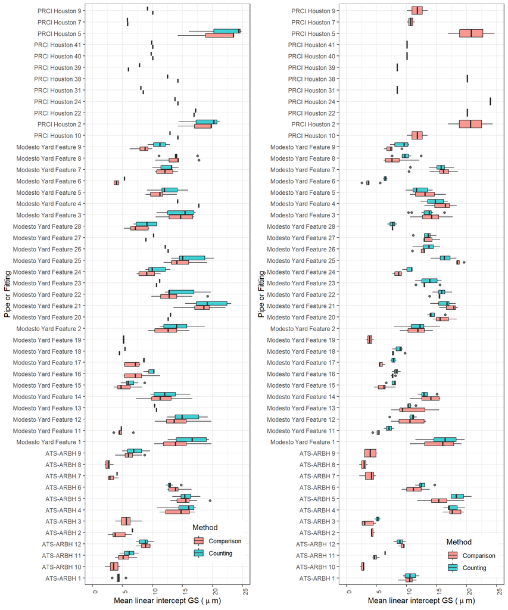

The purpose of these charts is qualitative identification and comparison of the features with small and large grains between the two analysis methods.

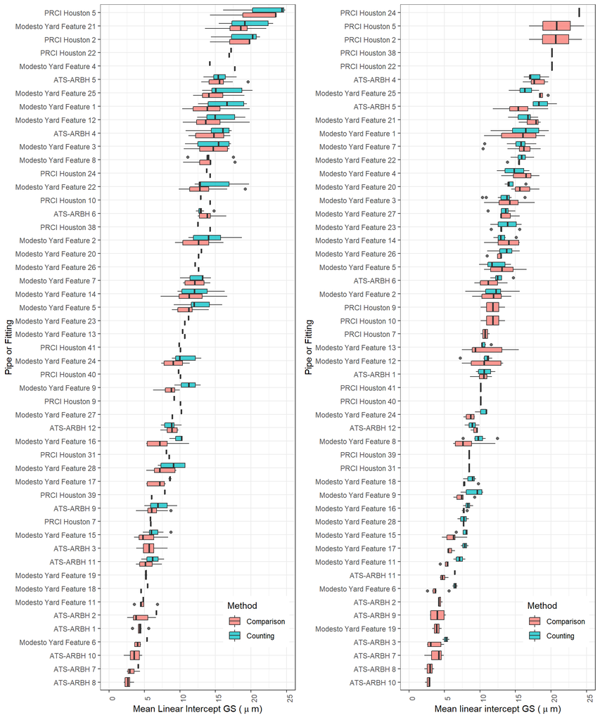

# 4 Dark Phase (DP) Evaluations

The data identified as erroneous (selected to “skip”) through the quality control (QC) process has been eliminated from this section. The purpose of the following charts is visualization of the data distribution.

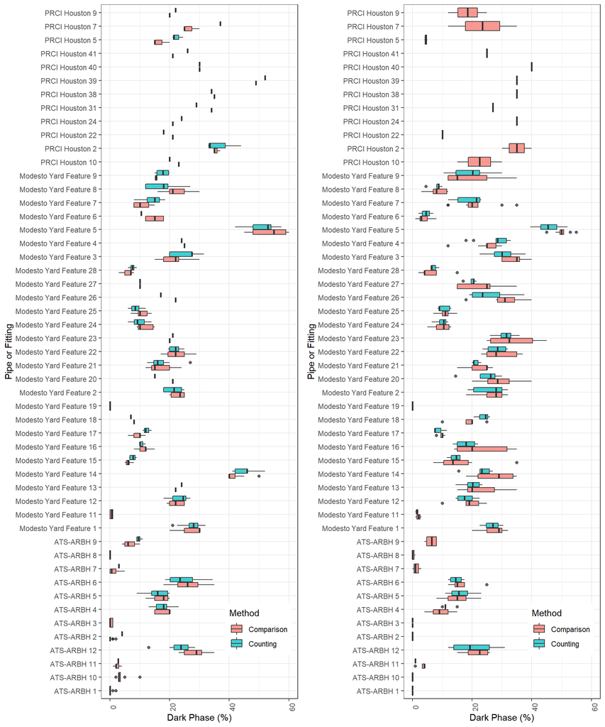

DP (%) evaluated for destructive cross-sections and replicas by the counting and comparison methods

The purpose of these charts is qualitative identification and comparison of the features with a small or large amount of dark phase between the two analysis methods.

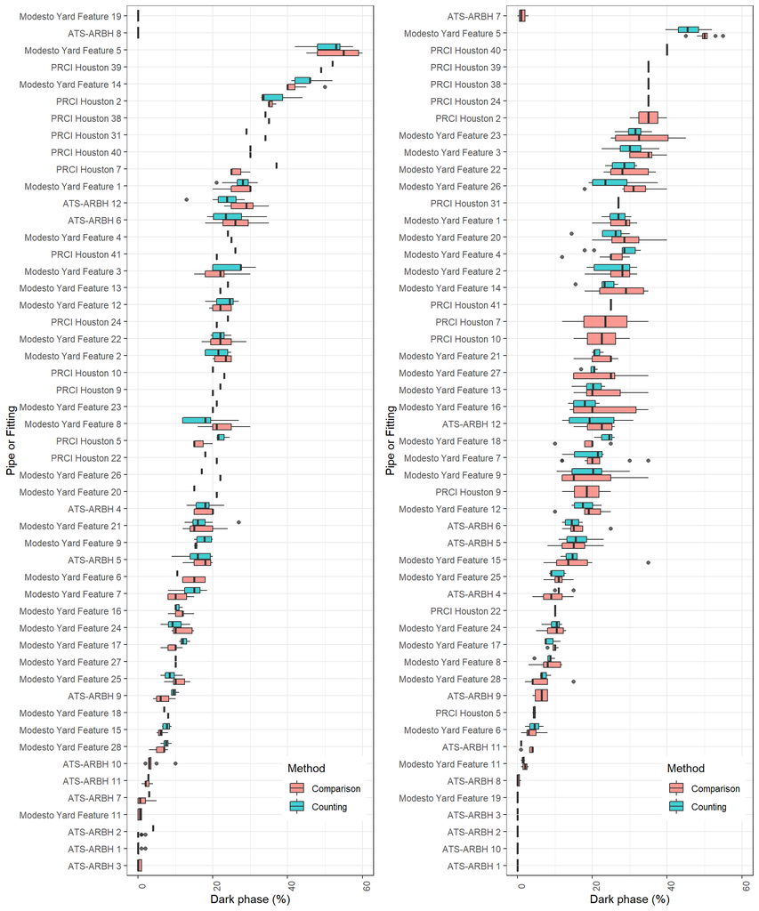

DP (%) evaluated for destructive cross-sections and replicas by the counting and comparison methods (ascending sort)

# 5 Validation of Microstructure Evaulation Method: Comparison vs Counting

Since we are using both comparison methods and counting methods, it is important to validate that the two methods provide similar results.

## 5.1 Grain Size

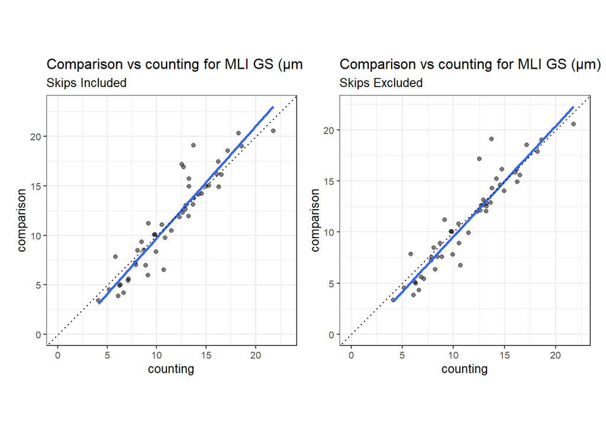

## 5.2 Dark Phase

The comparison method for dark phase is a method developed by PG&E, therefore is validated here vs the ASTM E562 counting method.

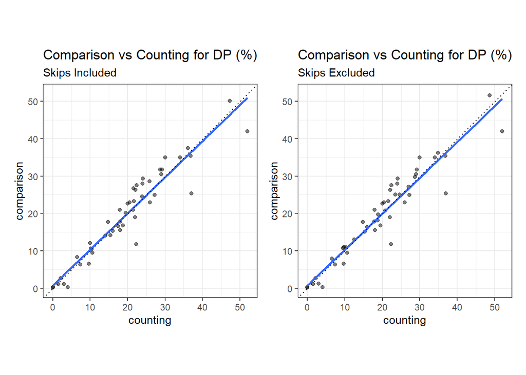

# 6 Validation of Sample Type: Replica vs Destructive Cross-Section

Since we are targeting the use of non-destructive methods for integrity management purposes, it is important to validate that the data from evaulations using replicas of the surface microstructure are similar to the data from evaluations using laboratory cross-sections of the pipes.

## 6.1 Grain Size

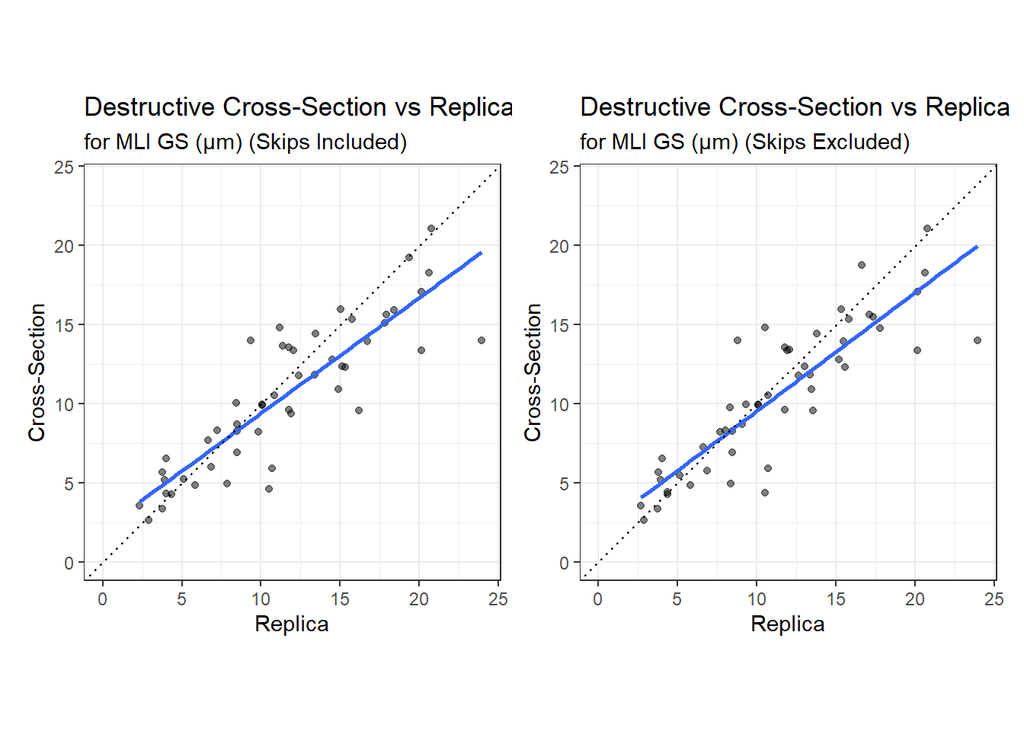

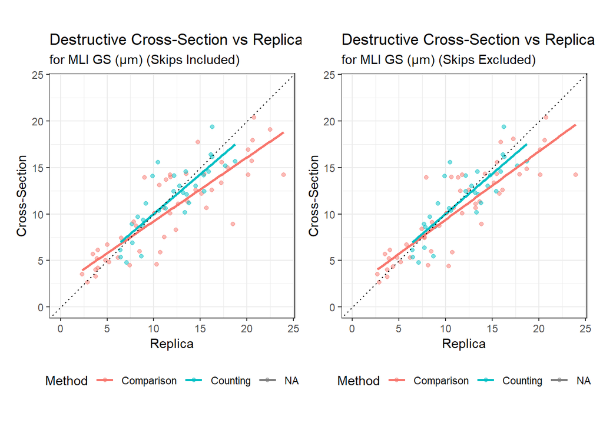

## 6.2 Dark Phase

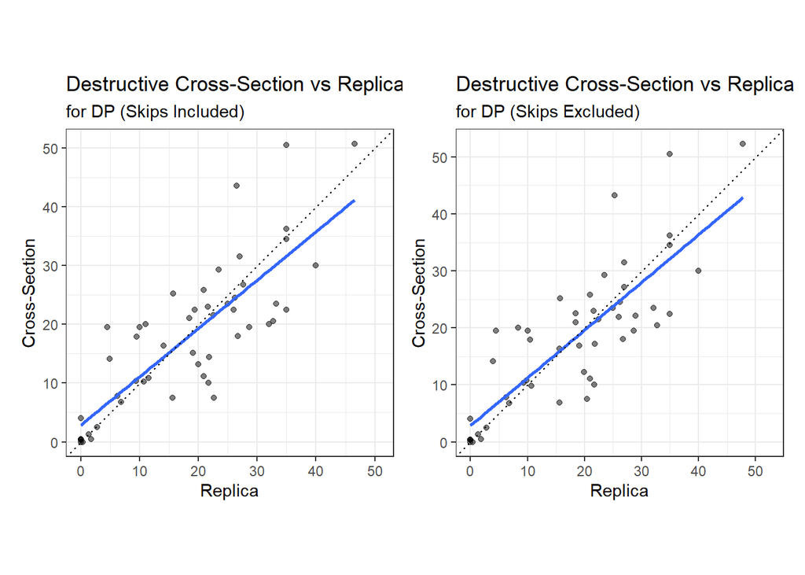

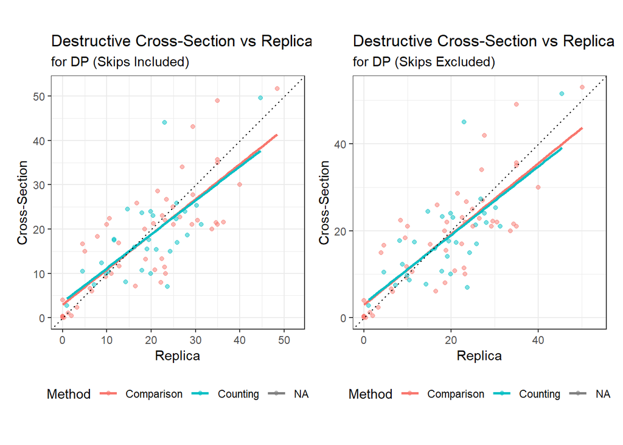

# 7 Correlations

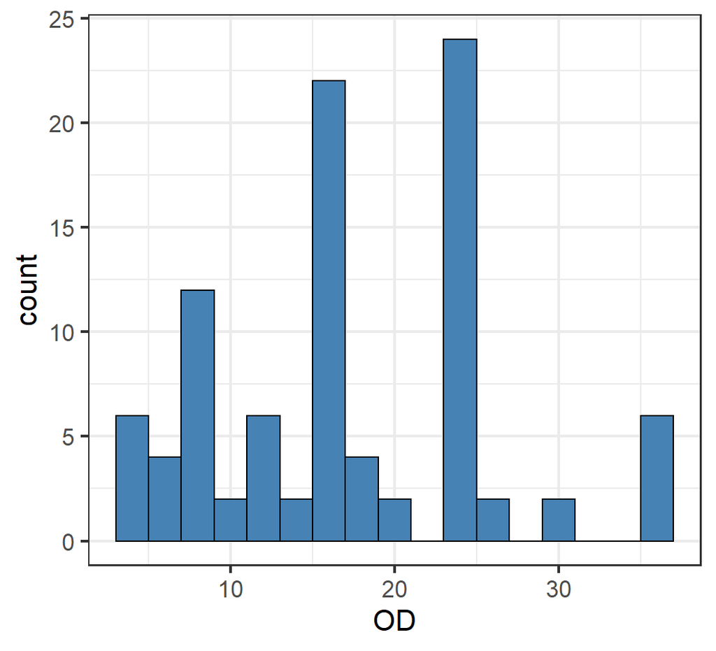

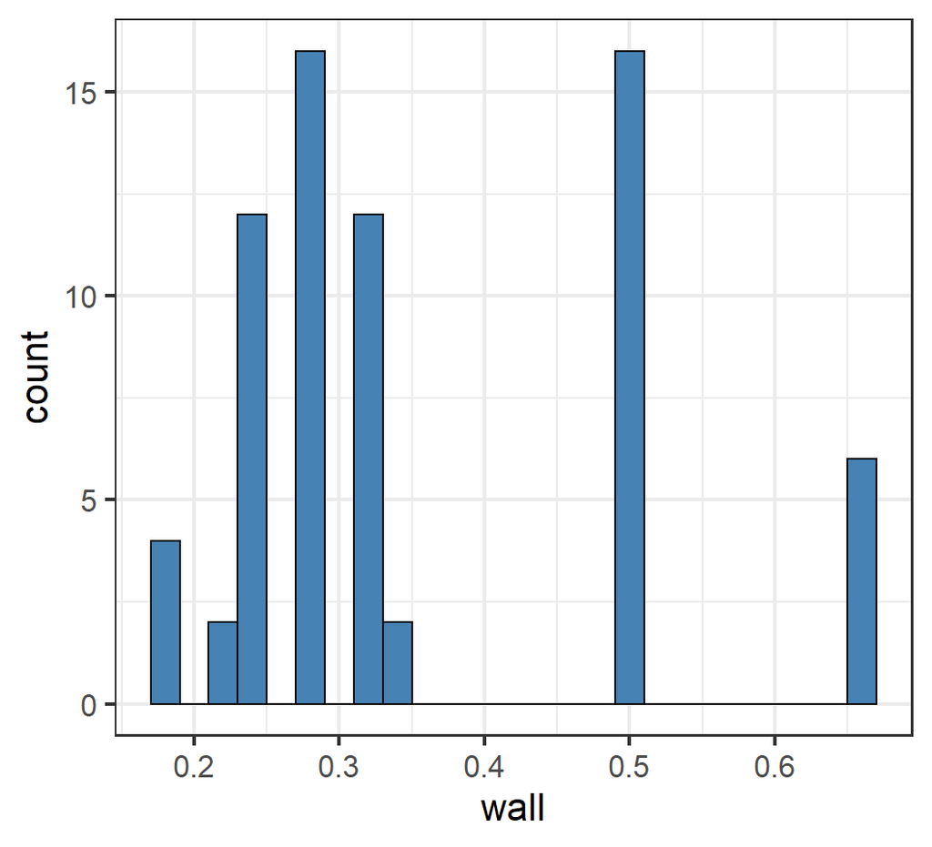

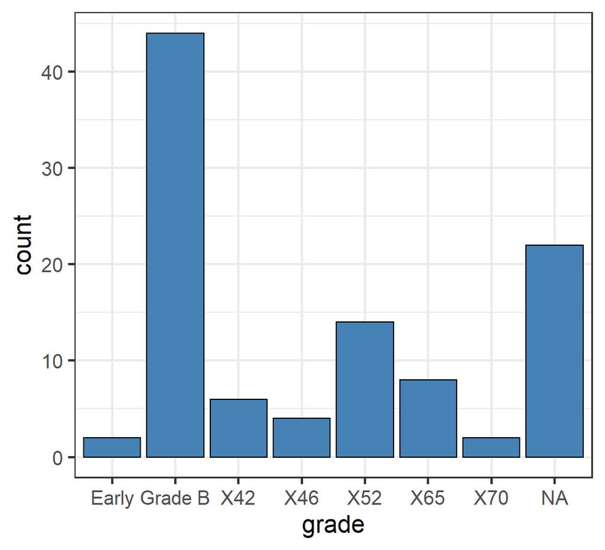

## 7.1 GS, DP, and Vintage

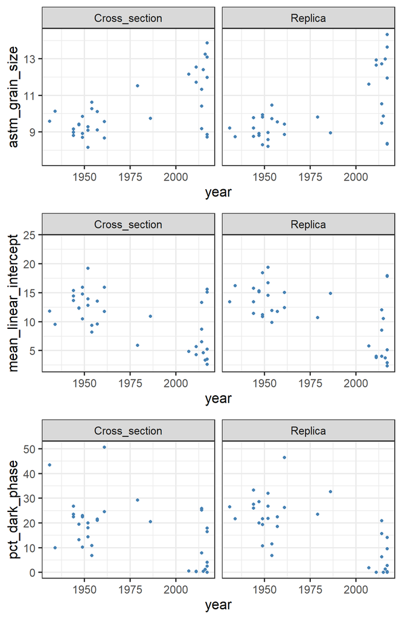

## 7.2 GS, DP, and Grade

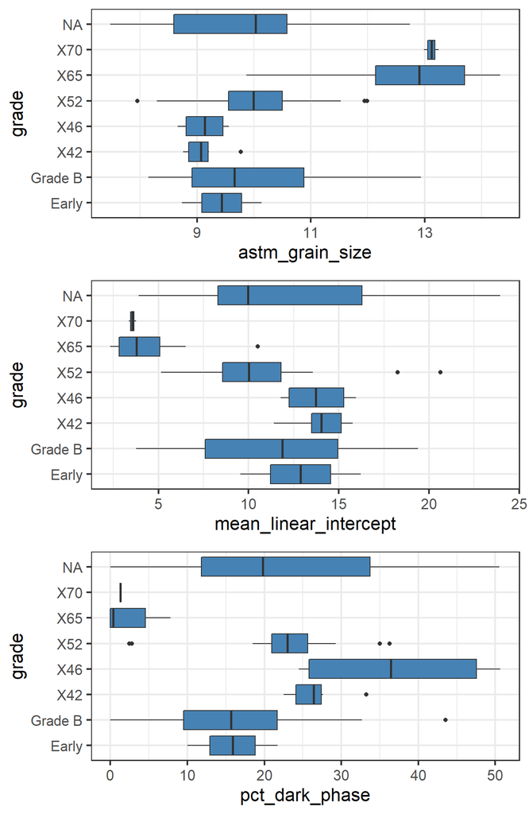

## 7.3 GS, DP, and Outside Diameter to Wall Thickness Ratio

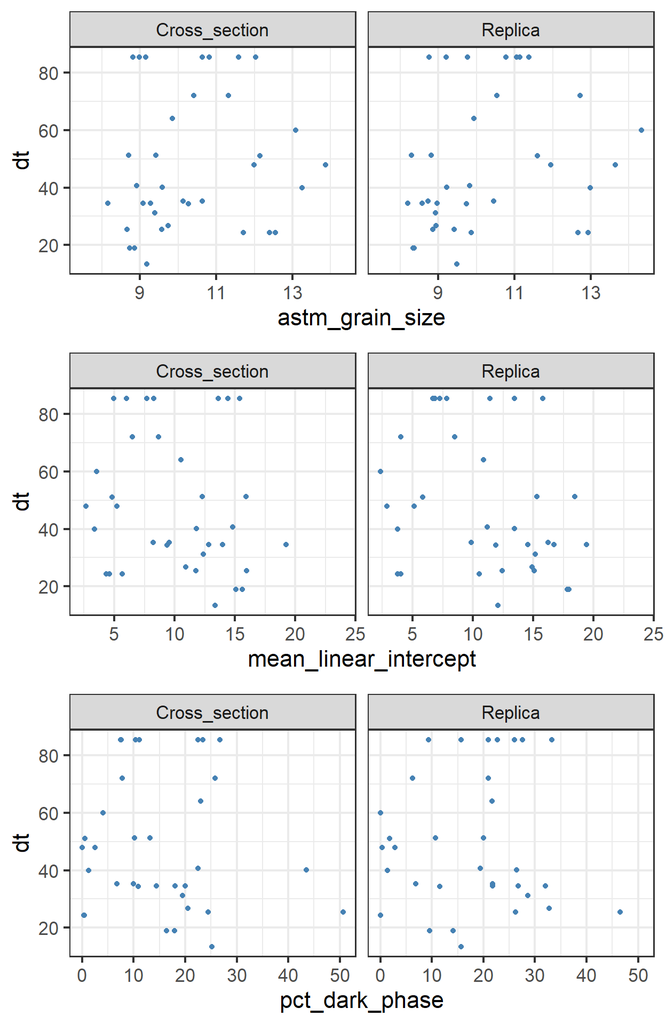

## 7.4 GS, DP, and Carbon Content

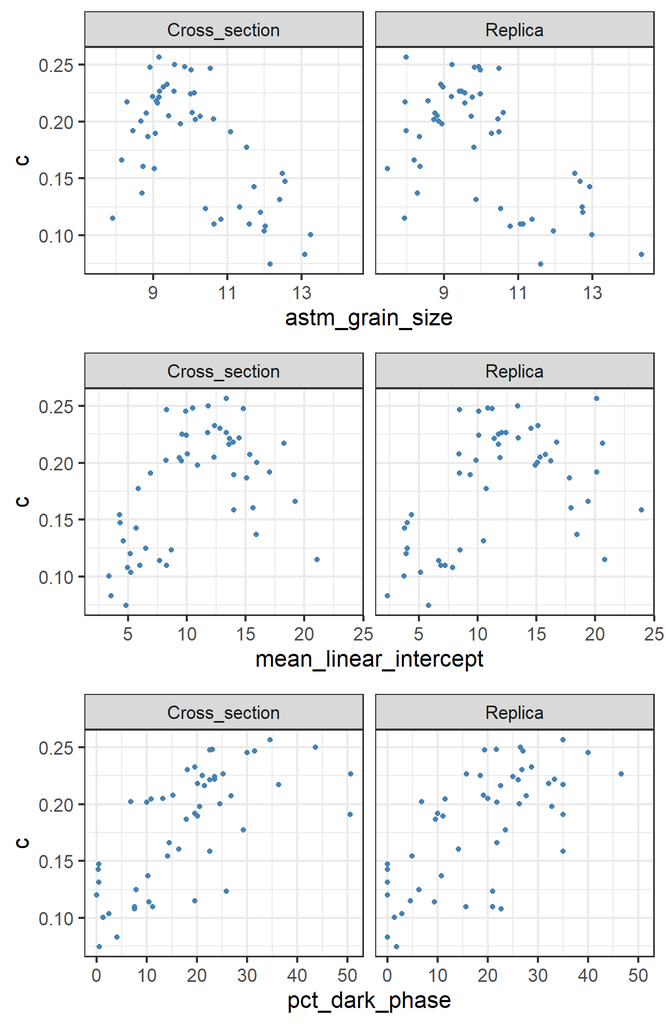

## 7.5 GS, DP, and Manganese Content

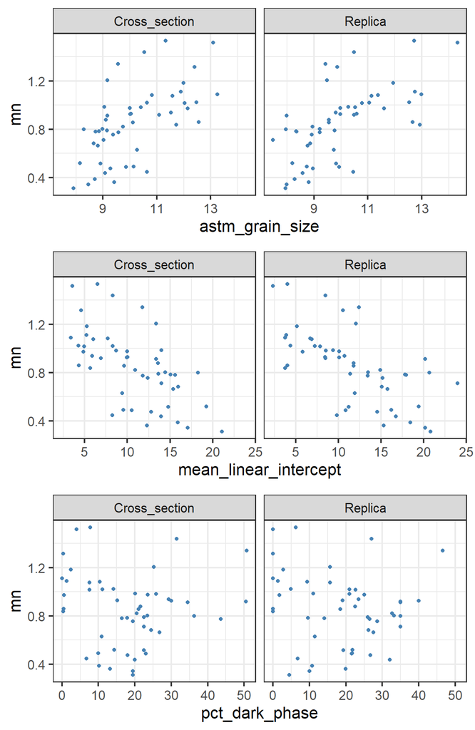

## 7.6 GS, DP, and Silicon Content

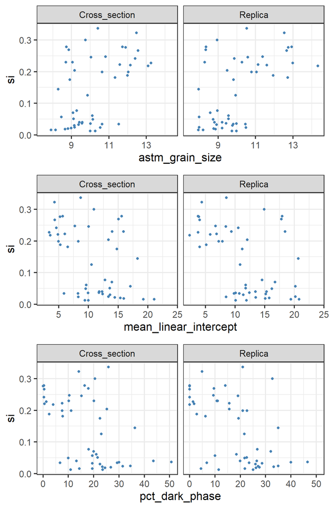

## 7.7 GS, DP, and Yield Strength

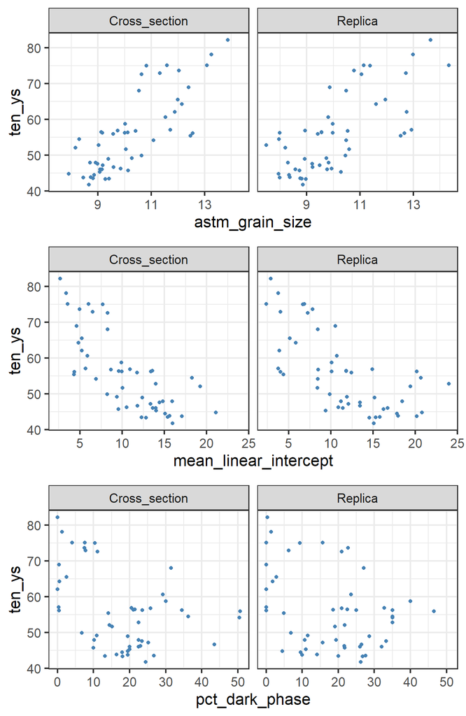

## 7.8 GS, DP, and Ultimate Tensile Strength

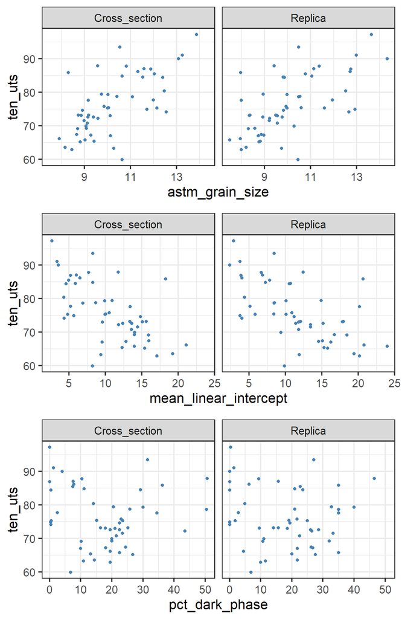

## 7.9 GS, DP, and Strain Hardening Exponent

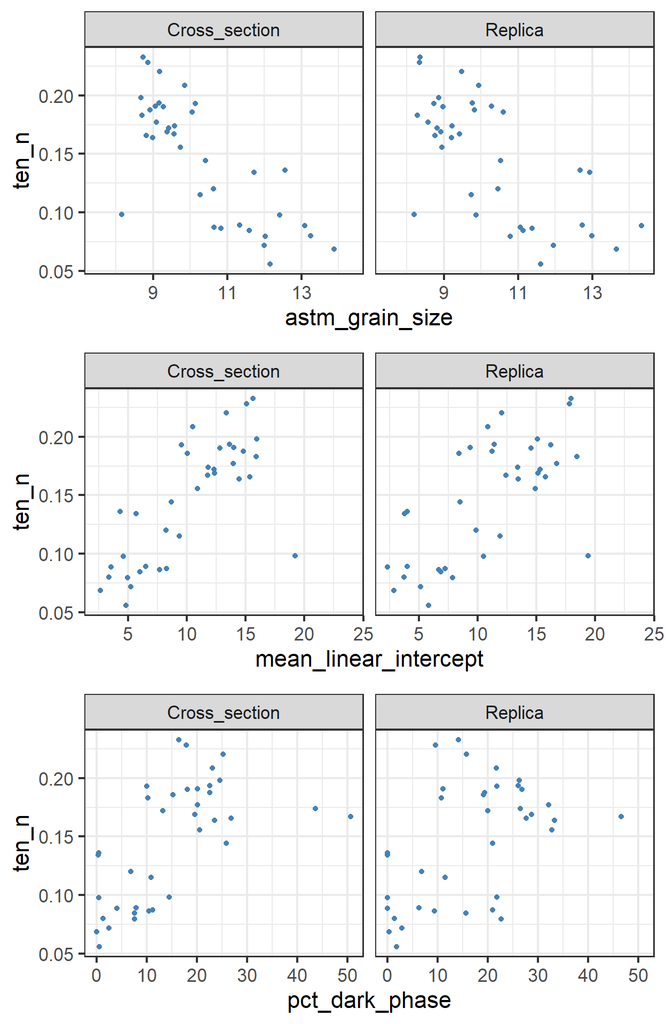

## 7.10 GS, DP, and IIT Predicted Yield Strength

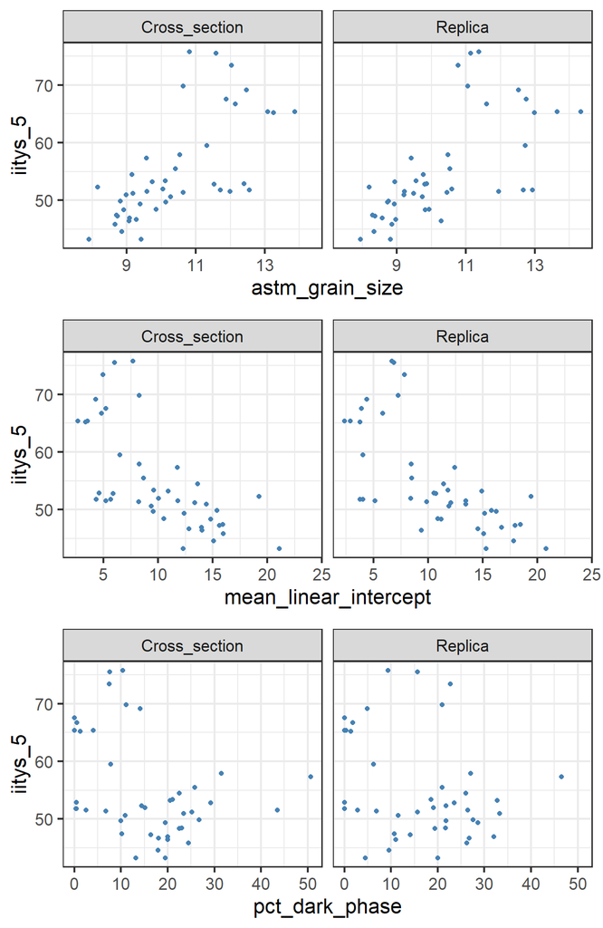

## 7.11 GS, DP, and IIT Predicted Ultimate Tensile Strength

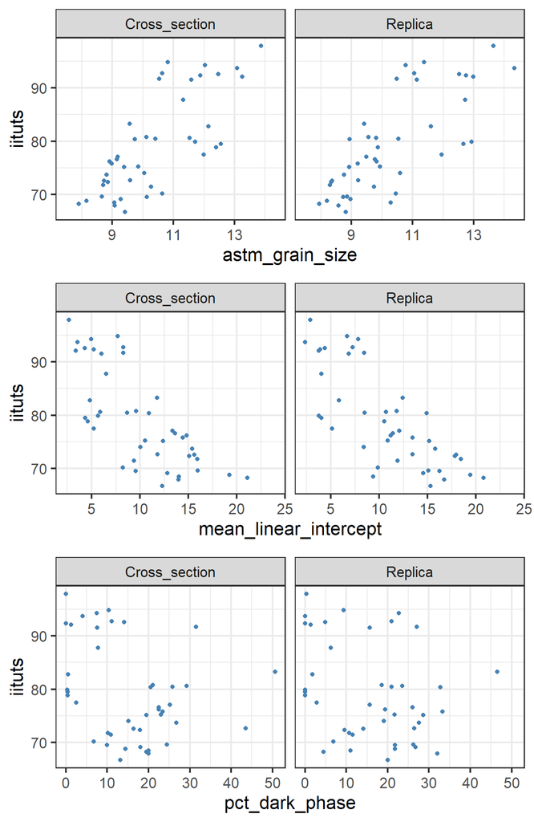

## 7.12 GS, DP, and Charpy V Notch Upper Shelf Energy

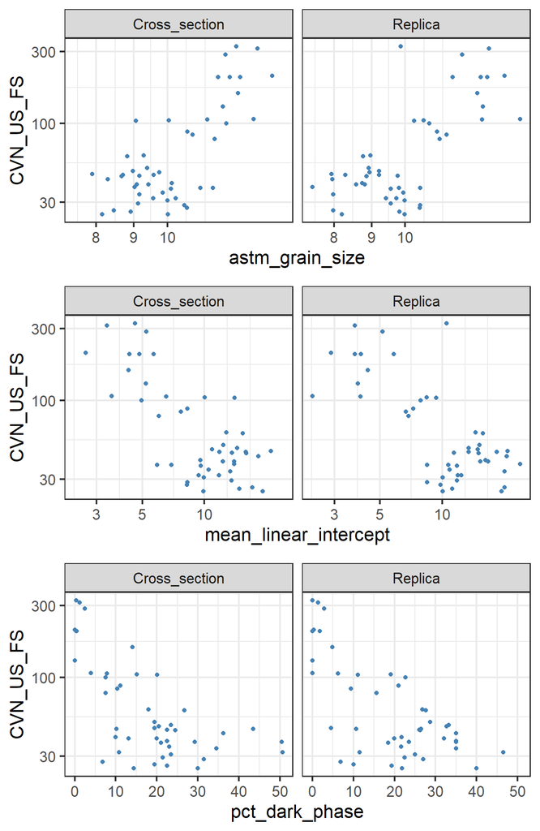

## 7.13 GS, DP, and Charpy V Notch Transition Temperature

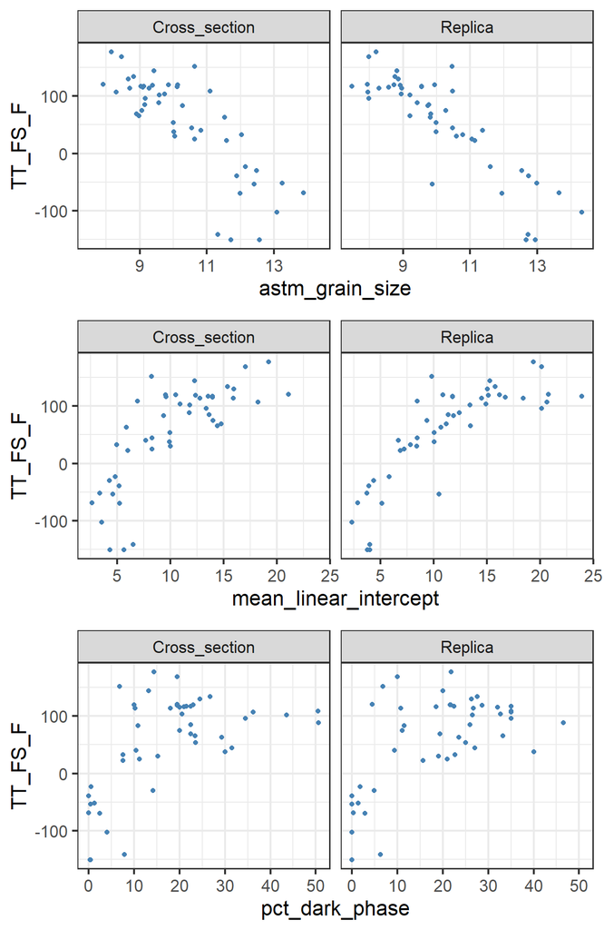